# Simulating Majora’s Mask Dog Race Minigame

[figure not shown]

# Introduction

This vignette demonstrates a **replication of the Majora’s Mask Dog Race** minigame mechanics in R. This work is inspired by a Vidya James YouTube video [Why Majora’s Mask’s Blue Dog Took 25 Years to Win the Race](https://www.youtube.com/watch?v=Y1l6Xj4PLEk), which discusses how the race functions in-game, and the information available from the **original C source code** hosted on the Majora’s Mask [zeldaret](https://github.com/zeldaret/mm) GitHub repository. The primary objective is to **estimate** each dog’s likelihood of winning by running a large number of **Monte Carlo** (random) simulations under the same rules used by the game. The main difference between Vidya James’ video and this analysis, is here we are examining if Blue dog can ever win, without relying on any glitches.

It is worth noting that this project was undertaken for fun. While I aimed to make it as robust as possible, there are likely mistakes and oversights. Specifically, since this involved coding in R, my conversion from C to R may not be the most efficient.

If you are not interested in the code and want to skip directly to the results, see Section 5. Spoiler: Blue dog never wins! :(

# Background: The Dog Race in Majora’s Mask

[figure not shown]

In **The Legend of Zelda: Majora’s Mask**, there is a dog-racing minigame at Romani Ranch. The player bets on one dog out of 14, then watches them race around a track. Several mechanics are defined in the source code:

1. **Base Speeds Vary by Colour**  
   The game’s code specifies different speeds for “White,” “Grey,” “Beige,” “Brown,” “Blue,” and “Gold” dogs, with a special “Default/Beige” case (which can essentially be ignored). These speeds can change during the race.
2. **Global Condition**  
   Each dog can be in “good” (faster by +20%), “neutral” (no change), or “bad” (slower by -20%) condition, assigned randomly. This further affects their performance.
3. **Sprint Mechanics**  
   Once the dog in first place crosses the 3/4 mark, a global sprint timer begins. Dogs that are not in bad condition get a speed multiplier that can reach up to 2.0 by the end of the race.
4. **Observing the Blue Dog**  
   Many players believe the **Blue dog never wins**, because while the Blue dog starts with a high speed for the first quarter, it can perform poorly afterwards. This experiment aims to verify this empirically by simulating many races and examining the results.

# Statistical (Monte Carlo) Approach

We replicate the mechanics of the race using **Monte Carlo** random sampling and a **time-step simulation**:

- **Data Definition**: We record each dog’s colour, condition, speeds, and the point at which they switch speeds.
- **Custom RNG**: Majora’s Mask uses a Linear Congruential Generator (LCG)[^1] for random floats, i.e., it updates a 32-bit integer state and converts it to a float in $[-0.5, +0.5]$.
- **Simulation**: Each dog’s position is tracked over time, and once all dogs finish, we see which one came in first.

Because we repeat this procedure $\text{n_sims}$ times, the fraction of races in which a specific dog finishes first becomes that dog’s **empirical winning rate**. While we often call it “probability” for simplicity, it is actually the **empirical estimate** of the dog’s chance to win under the same rules, seeds, and assumptions.

From the original game code, here is the snippet for the random function:

```r
f32 Rand_Centered(void) {
    sRandInt = (sRandInt * RAND_MULTIPLIER) + RAND_INCREMENT;
    gRandFloat.i = ((sRandInt >> 9) | 0x3F800000);
    return gRandFloat.f - 1.5f;
}
```

This produces floats in $[-0.5, 0.5]$. We replicate it in R by storing a seed, multiplying by the same constants, taking the result mod $2^{32}$, and shifting the float.

# 1. Data Frames and Constants

We start by defining the dog speeds (`sBaseSpeeds`), the 14 dog colours (`dog_colours`), and the condition distribution (4 good, 5 neutral, 5 bad).A table of each colour’s base speeds are shown below, for reference:

| Colour Index | Colour Name | First Speed | Second Speed |
| --- | --- | --- | --- |
| 0 | Default | 0.0 | 0.0 |
| 1 | White | 5.0 | 5.5 |
| 2 | Gray | 5.0 | 5.0 |
| 3 | Beige | 5.5 | 5.0 |
| 4 | Brown | 4.5 | 5.5 |
| 5 | Blue | 6.0 | 4.0 |
| 6 | Gold | 4.0 | 6.0 |

```r
###########################################
# 1. Data and Constants
###########################################

# sBaseSpeeds (in R, 1-based rows):
#   row1 => DOG_COLOR_DEFAULT(0) => {0.0, 0.0}
#   row2 => DOG_COLOR_WHITE  (1) => {5.0, 5.5}
#   row3 => DOG_COLOR_GRAY   (2) => {5.0, 5.0}
#   row4 => DOG_COLOR_BEIGE  (3) => {5.5, 5.0}
#   row5 => DOG_COLOR_BROWN  (4) => {4.5, 5.5}
#   row6 => DOG_COLOR_BLUE   (5) => {6.0, 4.0}
#   row7 => DOG_COLOR_GOLD   (6) => {4.0, 6.0}
sBaseSpeeds <- matrix(
  c(
    0.0, 0.0,   # row1 => Default
    5.0, 5.5,   # row2 => White
    5.0, 5.0,   # row3 => Gray
    5.5, 5.0,   # row4 => Beige
    4.5, 5.5,   # row5 => Brown
    6.0, 4.0,   # row6 => Blue
    4.0, 6.0    # row7 => Gold
  ),
  ncol = 2, byrow = TRUE
)

# The 14 dogs' colours, from sDogInfo in the game:
  #  dog 0 => 3 (Beige), dog 1 => 1 (White), dog 2 => 5 (Blue), dog 3 => 2 (Gray),
  #  dog 4 => 4 (Brown), dog 5 => 2 (Gray), dog 6 => 3 (Beige), dog 7 => 1 (White),
  #  dog 8 => 1 (White), dog 9 => 6 (Gold), dog 10 => 2 (Gray), dog 11 => 3 (Beige),
  #  dog 12 => 1 (White), dog 13 => 4 (Brown)
  dog_colours <- c(3,1,5,2,4,2,3,1,1,6,2,3,1,4)
  n_dogs      <- length(dog_colours)  # 14

  # Condition distribution: 4 good, 5 neutral, 5 bad
  dog_condition_types <- c(rep("good",4), rep("neutral",5), rep("bad",5))

  # from sDogInfo: the distance point to use second base speed
  #  in the game, these are path indices 8..10, but we map them
  #  to (index/12)*race_length in the code
  pt_to_use_2nd <- c(9,9,10,9,8,9,9,9,9,8,9,9,9,8)

  # Full colour labels (0..6 => 7 total). We'll exclude "Default" from final outputs.
  color_labels <- c("Default","White","Gray","Beige","Brown","Blue","Gold")


  ###########################################
  # 1a. Build dog_labels for finishing matrix
  ###########################################
  # Each dog gets a label like "beige_1", "white_1", "gray_1", etc.
  build_dog_labels <- function(dog_colours, color_labels) {
    color_counts <- setNames(as.list(rep(0L, length(color_labels))), color_labels)
    labels_out   <- character(length(dog_colours))

    for (i in seq_along(dog_colours)) {
      c_enum  <- dog_colours[i]
      # note +1 to handle R's 1-based row indexing
      c_label <- color_labels[c_enum + 1]
      color_counts[[c_label]] <- color_counts[[c_label]] + 1
      # e.g. "beige_1", "white_2", "blue_1", etc.
      labels_out[i] <- paste0(tolower(c_label), "_", color_counts[[c_label]])
    }
    labels_out
  }

  dog_labels <- build_dog_labels(dog_colours, color_labels)

  # Condition multiplier function
  # Good => ×1.2, Bad => ÷1.2, Neutral => ×1.0
  condition_multiplier <- function(cond) {
    if (cond == "good") return(1.2)
    if (cond == "bad")  return(1/1.2)
    1.0
  }
```

# 2. Custom RNG

We use a **double-precision** LCG to avoid integer overflow in R, but otherwise mirror the game code’s approach to generating random floats:

```r
  ###########################################
  # 2. RNG (LCG) Implementation in R
  ###########################################
  # We store the seed as a double in [0, 2^32)
  # to avoid integer overflow in 32-bit multiplication.

  RNGenv <- new.env()
  RNGenv$seed <- 0.0  # user can set, e.g. RNGenv$seed <- 1234.0

  rand_centered_float <- function(range = 1.0) {
    # The constants 1664525 and 1013904223 are from the original code
    RNGenv$seed <- (RNGenv$seed * 1664525 + 1013904223) %% 4294967296
    # convert [0,1) => [-0.5,0.5] => scale by 'range'
    ((RNGenv$seed / 4294967296) - 0.5) * range
  }
```

# 3. The Simulation Function

Our function `simulate_dograce` (see below) performs the following:

1. Randomly assigns conditions to each dog.
2. Sets each dog’s initial speed (Blue gets a special speed for the first quarter).
3. Iterates over time, updating speeds if the dog in first crosses 3/4, applying condition multipliers, etc.
4. Once all dogs finish, records their final ranks.
5. Repeats for $\text{n_sims}$ runs, so we can **count** how many times each dog finishes first.

```r
  ###########################################
  # 3. Main Simulation Function
  ###########################################
  simulate_dograce <- function(n_sims,
                               race_length = 1000,
                               selected_dog = 1,  # can be numeric or a string label
                               show_progress = TRUE) {
    # 3.1. Convert selected_dog to numeric if string
    if (is.character(selected_dog)) {
      dog_index <- match(selected_dog, dog_labels)
      if (is.na(dog_index)) {
        stop("Error: 'selected_dog' label not found in dog_labels. Provided: ", selected_dog)
      }
      selected_dog <- dog_index
    } else if (!is.numeric(selected_dog)) {
      stop("selected_dog must be numeric or character.")
    }

    # Safety: ensure the numeric index is in 1..n_dogs
    if (selected_dog < 1 || selected_dog > n_dogs) {
      stop("selected_dog numeric index out of range (1..", n_dogs, ").")
    }

    finish_matrix  <- matrix(0, nrow = n_sims, ncol = n_dogs)
    winners        <- integer(n_sims)
    winner_colours <- integer(n_sims)

    # create a progress bar
    if (show_progress) {
      pb <- txtProgressBar(min = 0, max = n_sims, style = 3)
    }

    ###########################################
    # Function to simulate one race
    ###########################################
    simulate_one_race <- function() {
      # randomly assign 4 good, 5 neutral, 5 bad
      assigned_conds <- sample(dog_condition_types, n_dogs, replace = FALSE)

      # Build dog_data for all 14 dogs
      dog_data <- lapply(seq_len(n_dogs), function(i) {
        list(
          colour       = dog_colours[i],
          condition    = assigned_conds[i],
          dist_for_2nd = (pt_to_use_2nd[i] / 12) * race_length,
          sprint_mult  = NA_real_,
          finished     = FALSE,
          finish_rank  = NA_integer_,
          position     = 0.0,
          speed        = 0.0
        )
      })

      # sSprintTimer increments once the first-place dog passes 3/4
      sSprintTimer      <- 0
      quarter_len       <- 0.25 * race_length
      three_quarter_len <- 0.75 * race_length

      # At race start, if dog is Blue(enum=5), use sBaseSpeeds[6,1]=6.0
      # Others => 5.0
      for (k in seq_len(n_dogs)) {
        col <- dog_data[[k]]$colour
        if (col == 5) {
          dog_data[[k]]$speed <- sBaseSpeeds[col + 1, 1]  # row6 => 6.0
        } else {
          dog_data[[k]]$speed <- 5.0
        }
      }

      get_first_place <- function(dd) which.max(vapply(dd, `[[`, numeric(1), "position"))

      ###########################################
      # Speed update logic each step
      ###########################################
      update_speeds <- function(dd, sprint_time) {
        idx_first <- get_first_place(dd)
        for (k in seq_along(dd)) {
          dpos <- dd[[k]]$position
          col  <- dd[[k]]$colour
          cond <- dd[[k]]$condition

          base_spd <- 0.0
          if (dpos < quarter_len) {
            # first quarter
            if (col == 5) {
              base_spd <- sBaseSpeeds[col + 1, 1] + rand_centered_float(1.0)
            } else {
              base_spd <- 5.0 + rand_centered_float(1.0)
            }

          } else if (dpos < three_quarter_len) {
            # from 1/4 to 3/4
            if (dpos >= dd[[k]]$dist_for_2nd) {
              base_spd <- sBaseSpeeds[col + 1, 2] + rand_centered_float(1.0)
            } else {
              base_spd <- 5.0 + rand_centered_float(1.0)
            }

          } else {
            # final 1/4
            # if sprint_mult not set, do it now (unless bad)
            if (is.na(dd[[k]]$sprint_mult)) {
              if (cond == "bad") {
                dd[[k]]$sprint_mult <- 1.0
              } else {
                # 2.0 max if sSprintTimer >=100
                if (sprint_time < 100) {
                  dd[[k]]$sprint_mult <- 200.0 / (200.0 - sprint_time)
                } else {
                  dd[[k]]$sprint_mult <- 2.0
                }
              }
            }
            base_spd <- sBaseSpeeds[col + 1, 2] + rand_centered_float(1.0)
            base_spd <- base_spd * dd[[k]]$sprint_mult
          }

          # Apply condition multiplier
          base_spd <- base_spd * condition_multiplier(cond)

          # The selected dog has a cap of 7.5, others 7.0
          max_spd <- if (k == selected_dog) 7.5 else 7.0
          base_spd <- min(base_spd, max_spd)

          dd[[k]]$speed <- base_spd
        }
        dd
      }

      # Step until all 14 dogs finish
      rank_counter <- 0
      while (rank_counter < n_dogs) {
        idx_first <- get_first_place(dog_data)

        # increment sSprintTimer once first-place dog crosses 3/4
        if (!dog_data[[idx_first]]$finished &&
            dog_data[[idx_first]]$position >= three_quarter_len) {
          sSprintTimer <- sSprintTimer + 1
        }

        # update speeds
        dog_data <- update_speeds(dog_data, sSprintTimer)

        # move dogs
        for (k in seq_along(dog_data)) {
          if (!dog_data[[k]]$finished) {
            dog_data[[k]]$position <- dog_data[[k]]$position + dog_data[[k]]$speed
            if (dog_data[[k]]$position >= race_length) {
              dog_data[[k]]$finished <- TRUE
              rank_counter <- rank_counter + 1
              dog_data[[k]]$finish_rank <- rank_counter
            }
          }
        }
      }

      dog_data
    }

    ###########################################
    # 3.2. Run all simulations
    ###########################################
    for (sim_id in seq_len(n_sims)) {
      race_result <- simulate_one_race()

      # record finishing ranks
      for (j in seq_len(n_dogs)) {
        finish_matrix[sim_id, j] <- race_result[[j]]$finish_rank
      }

      # find the winner (rank=1)
      dog_winner <- which.min(vapply(race_result, `[[`, numeric(1), "finish_rank"))
      winners[sim_id]        <- dog_winner
      winner_colours[sim_id] <- race_result[[dog_winner]]$colour

      # update progress bar if desired
      if (show_progress) {
        setTxtProgressBar(pb, sim_id)
      }
    }

    if (show_progress) {
      close(pb)
    }

    ###########################################
    # 4. Summarise results
    ###########################################
    dog_win_counts   <- tabulate(winners, nbins = n_dogs)
    dog_win_probs    <- dog_win_counts / n_sims

    # colour is 0..6 => shift by +1 for R indexing
    col_win_counts <- tabulate(winner_colours + 1, nbins = length(color_labels))
    col_win_probs  <- col_win_counts / n_sims

    mean_finish_positions <- colMeans(finish_matrix)

    # Remove "Default" from final colour results
    col_win_probs_no_def    <- col_win_probs[-1]
    color_labels_no_default <- color_labels[-1]

    # Races for 99.99% chance => (1 - p)^N <= 0.0001 => N >= log(0.0001)/log(1 - p)
    races_for_99_99 <- sapply(col_win_probs_no_def, function(p) {
      if (p <= 0) return(Inf)
      ceiling(log(0.0001) / log(1 - p))
    })

    # Name dog-based results with dog_labels
    dog_win_prob_named <- setNames(dog_win_probs, dog_labels)
    colnames(finish_matrix) <- dog_labels
    mean_finish_positions_named  <- setNames(mean_finish_positions, dog_labels)

    # Name colour-based results (excluding "Default")
    colour_win_probability_named <- setNames(col_win_probs_no_def, color_labels_no_default)
    races_for_99_99_named        <- setNames(races_for_99_99,      color_labels_no_default)

    ###########################################
    # Final output
    ###########################################
    list(
      dog_win_probability        = sort(dog_win_prob_named, decreasing = T),
      colour_win_probability     = sort(colour_win_probability_named, decreasing = T),
      mean_finish_position       = sort(mean_finish_positions_named, decreasing = F),
      races_for_99_99_per_colour = races_for_99_99_named,
      finish_positions_all       = finish_matrix
    )
  }
```

### Calculating “Probabilities”

After running $\text{n_sims}$ races, we simply tally **how often** each dog finishes in first place, then divide by $\text{n_sims}$. This yields an **empirical** or **Monte Carlo** approximation of that dog’s winning chance:

$$\hat{p}_i \;=\; \frac{\text{(number of times dog $i$
won)}}{\text{n\_sims}}.$$

As $\text{n_sims}$ grows large, $\hat{p}_i$ converges to the dog’s true probability of winning under these rules.

### Computing the 99.99% “Guarantee”

We also calculate the number of races needed for a **99.99% chance** of at least one victory for each colour. If the colour’s empirical winning rate is $p$, then the probability it fails to win in $N$ races is $(1 - p)^N$. For a 99.99% success chance:

$$(1 - p)^N \; \le \; 0.0001
\quad\Longrightarrow\quad
N \;\ge\; \frac{\ln(0.0001)}{\ln(1 - p)}.$$

In the simulation’s output list, we apply this to each colour’s $\hat{p}$.

# 4. Running the Simulation

Below is an example of running 100,000 races where **Gold** is selected, then another 100,000 with **Blue** selected. (We keep the code in one chunk for clarity.) The reasoning behind running the simulation twice with different selected dogs is it seems that there is a small speed bonus applied to the uer selected dog.

```r
  # Run simulation with gold dog selected by player
  set.seed(1701)        # controls R's default RNG for sample()
  RNGenv$seed <- 1701.0  # RNG function seed
  results_gold <- simulate_dograce(n_sims = 100000, race_length = 1000, selected_dog = 'gold_1', show_progress = TRUE)
  results_gold$dog_win_probability
  results_gold$colour_win_probability
  results_gold$mean_finish_position
  results_gold$races_for_99_99_per_colour
  head(results_gold$finish_positions_all)

  # Run simulation with blue dog selected by player
  set.seed(1701)        # controls R's default RNG for sample()
  RNGenv$seed <- 1701.0  # RNG function seed
  results_blue <- simulate_dograce(n_sims = 100000, race_length = 1000, selected_dog = 'blue_1', show_progress = TRUE)
  results_blue$dog_win_probability
  results_blue$colour_win_probability
  results_blue$mean_finish_position
  results_blue$races_for_99_99_per_colour
  head(results_blue$finish_positions_all)
```

# 5. Results and Visualisations

## 5.1 Gold Dog Selected

When we select the Gold dog, we see in Figure 1 below that “gold_1” has an **empirical winning rate** of around 28%, while “blue_1” has 0%, indicating that across 100,000 trials, Blue did not win once in this scenario.

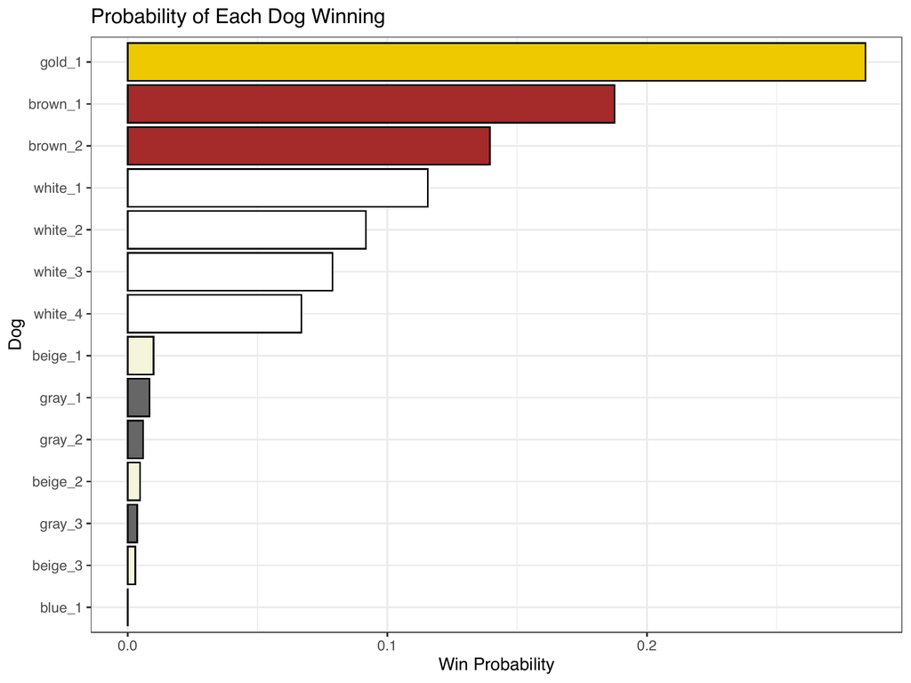

Figure 1: Estimated win rate of each dog when the selected dog is “Gold”. “Gold” dog wins areound 28% of the time. Blue dog never wins!

```r
  library(ggplot2)

  # set up colours for plot
  dog_color_map <- c(
    "BEIGE" = "beige",
    "WHITE" = "white",
    "BLUE"  = "darkslateblue",
    "GOLD"  = "gold2",
    "BROWN" = "brown",
    "GRAY"  = "gray40"
  )

  # Helper function: extract the uppercase colour name
  # from a dog label such as "beige_1", "white_2", etc.
  extract_colour_name <- function(dog_label) {
    # 1) remove anything after the underscore => "beige"
    # 2) convert to uppercase => "BEIGE"
    # e.g. "beige_1" => "BEIGE"
    toupper(sub("_.*", "", dog_label))
  }

  df_dogs <- data.frame(
    Dog     = names(results_gold$dog_win_probability),
    WinProb = as.numeric(results_gold$dog_win_probability)
  )

  # Create a new column "ColourName" for the dog's actual colour
  df_dogs$ColourName <- sapply(df_dogs$Dog, extract_colour_name)

  ggplot(df_dogs, aes(x = reorder(Dog, WinProb), y = WinProb, fill = ColourName)) +
    geom_col(show.legend = FALSE, col = 'black') +
    coord_flip() +
    labs(
      title = "Probability of Each Dog Winning",
      x = "Dog",
      y = "Win Probability"
    ) +
    scale_fill_manual(values = dog_color_map) +
    theme_bw()
```

### Mean Finish Positions

Figure 2 shows the **mean finishing position** of each dog for the gold-selected scenario. Lower means a better average finish (i.e., they place nearer 1st more often). Gold naturally does well, with a mean finish near 5.5, while Blue is near 9, reflecting its struggle to maintain speed in later segments.

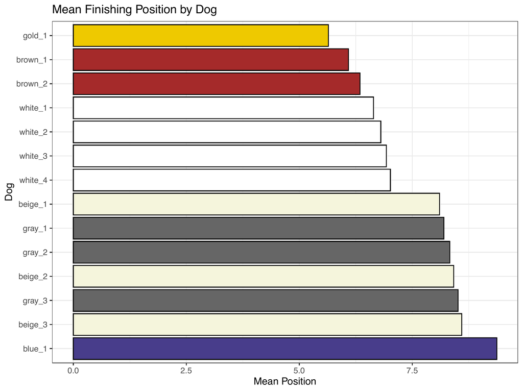

Figure 2: Average finish postion for each dog when the Gold dog is selected.

```r
  df_meanpos <- data.frame(
    Dog = names(results_gold$mean_finish_position),
    MeanPos = as.numeric(results_gold$mean_finish_position)
  )

  df_meanpos$ColourName <- sapply(df_meanpos$Dog, extract_colour_name)

  ggplot(df_meanpos, aes(x = reorder(Dog, -MeanPos), y = MeanPos, fill = ColourName)) +
    geom_col(show.legend = FALSE, col = 'black') +
    coord_flip() +
    labs(
      title = "Mean Finishing Position by Dog",
      x = "Dog",
      y = "Mean Position"
    ) +
    scale_fill_manual(values = dog_color_map) +
    theme_bw()
```

### Rank Distribution

Figure 3 displays how often each dog finishes at each rank (1..14). Notice that all dogs have multi-modal distributions (specifically 3 modes), reflecting the interplay of condition (good, neutral, bad) and random fluctuations. Many of the dogs show a similar rank distribution with the exception of the Gold and Blue dog, which show the Gold dog in a low (winning) position when the ‘good’ condition is applied. Conversly, the Blue dog peaks at around 4th position while the good condition is applied.

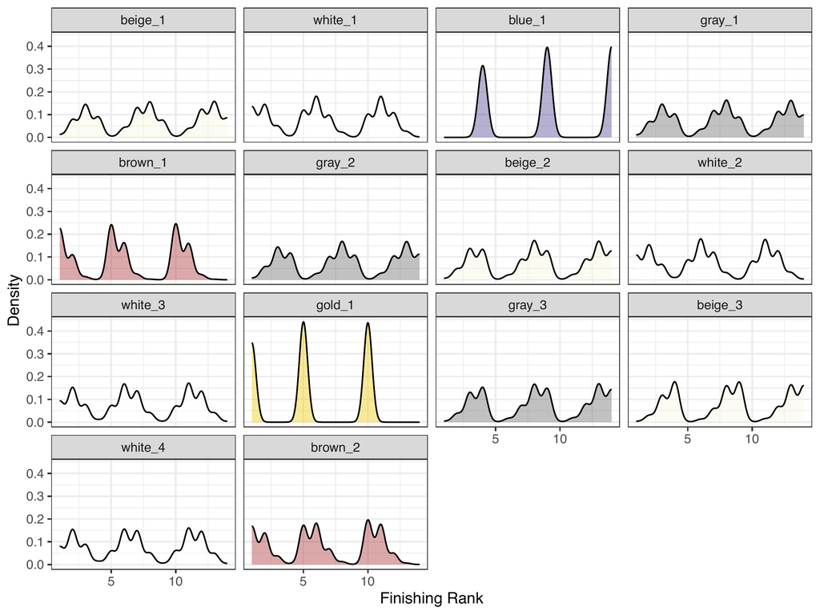

Figure 3: Rank distribution for each dog. Here we can see that each mode corresponds to either a good, bad, or neutral condtion.

```r
  finish_df <- melt(results_gold$finish_positions_all)
  colnames(finish_df) <- c("Simulation", "Dog", "FinishRank")

  # Extract the dog's actual colour
  finish_df$ColourName <- sapply(finish_df$Dog, extract_colour_name)

  ggplot(finish_df, aes(x = FinishRank, fill = ColourName)) +
    geom_density(alpha = 0.4, show.legend = FALSE) +
    facet_wrap(~ Dog) +
    labs(
      x = "Finishing Rank",
      y = "Density"
    ) +
    scale_fill_manual(values = dog_color_map) +
    theme_bw()
```

## 5.2 Blue Dog Selected

Running the same 100,000 races but selecting the Blue dog changes the results only slightly. In Figure 4, we again see Gold near 28% and Blue near 0%. This suggests that Blue struggles, even with the slight speed-cap boost for being selected.

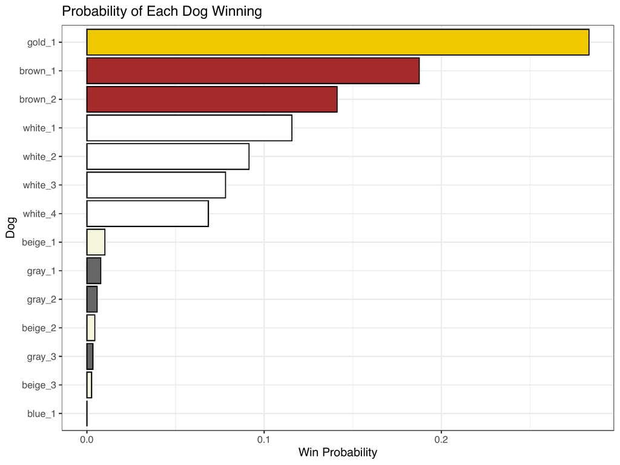

Figure 4: Win rate when the Blue dog is selected.

```r
  library(ggplot2)

  # set up colours for plot
  dog_color_map <- c(
    "BEIGE" = "beige",
    "WHITE" = "white",
    "BLUE"  = "darkslateblue",
    "GOLD"  = "gold2",
    "BROWN" = "brown",
    "GRAY"  = "gray40"
  )

  # Helper function: extract the uppercase colour name
  # from a dog label such as "beige_1", "white_2", etc.
  extract_colour_name <- function(dog_label) {
    # 1) remove anything after the underscore => "beige"
    # 2) convert to uppercase => "BEIGE"
    # e.g. "beige_1" => "BEIGE"
    toupper(sub("_.*", "", dog_label))
  }

  df_dogs <- data.frame(
    Dog     = names(results_blue$dog_win_probability),
    WinProb = as.numeric(results_blue$dog_win_probability)
  )

  # Create a new column "ColourName" for the dog's actual colour
  df_dogs$ColourName <- sapply(df_dogs$Dog, extract_colour_name)

  ggplot(df_dogs, aes(x = reorder(Dog, WinProb), y = WinProb, fill = ColourName)) +
    geom_col(show.legend = FALSE, col = 'black') +
    coord_flip() +
    labs(
      title = "Probability of Each Dog Winning",
      x = "Dog",
      y = "Win Probability"
    ) +
    scale_fill_manual(values = dog_color_map) +
    theme_bw()
```

### Mean Finish Positions (Blue-Selected)

In Figure 5, we see the average finishing rank again: Gold is around 5.65, Blue near 9.35. Over many simulations, Blue’s early speed advantage does not compensate for its later slowdown.

```r
  df_meanpos <- data.frame(
    Dog = names(results_blue$mean_finish_position),
    MeanPos = as.numeric(results_blue$mean_finish_position)
  )

  df_meanpos$ColourName <- sapply(df_meanpos$Dog, extract_colour_name)

  ggplot(df_meanpos, aes(x = reorder(Dog, -MeanPos), y = MeanPos, fill = ColourName)) +
    geom_col(show.legend = FALSE, col = 'black') +
    coord_flip() +
    labs(
      title = "Mean Finishing Position by Dog",
      x = "Dog",
      y = "Mean Position"
    ) +
    scale_fill_manual(values = dog_color_map) +
    theme_bw()
```

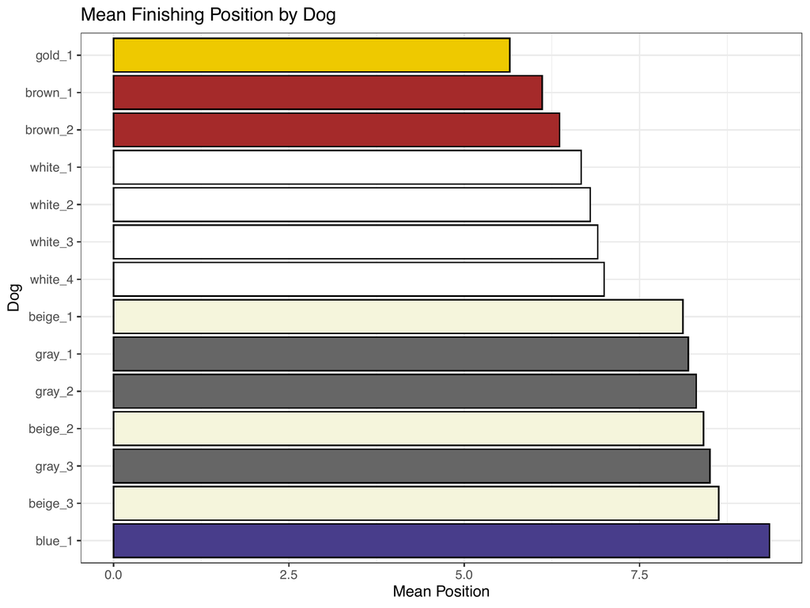

Figure 5: Average finish position for all dogs when the Blue dog is selected.

```r
  knitr::include_graphics("https://raw.githubusercontent.com/AlanInglis/Majoras_Mask_Blue_Dog/refs/heads/main/mm_plots/avg_fin_pos_blue.png")
```

### Rank Distribution (Blue-Selected)

Figure 6 shows the rank density plots again, still with multi-modal patterns for each dog.Again, the result basicaly missor those when the Gold dog is selected.

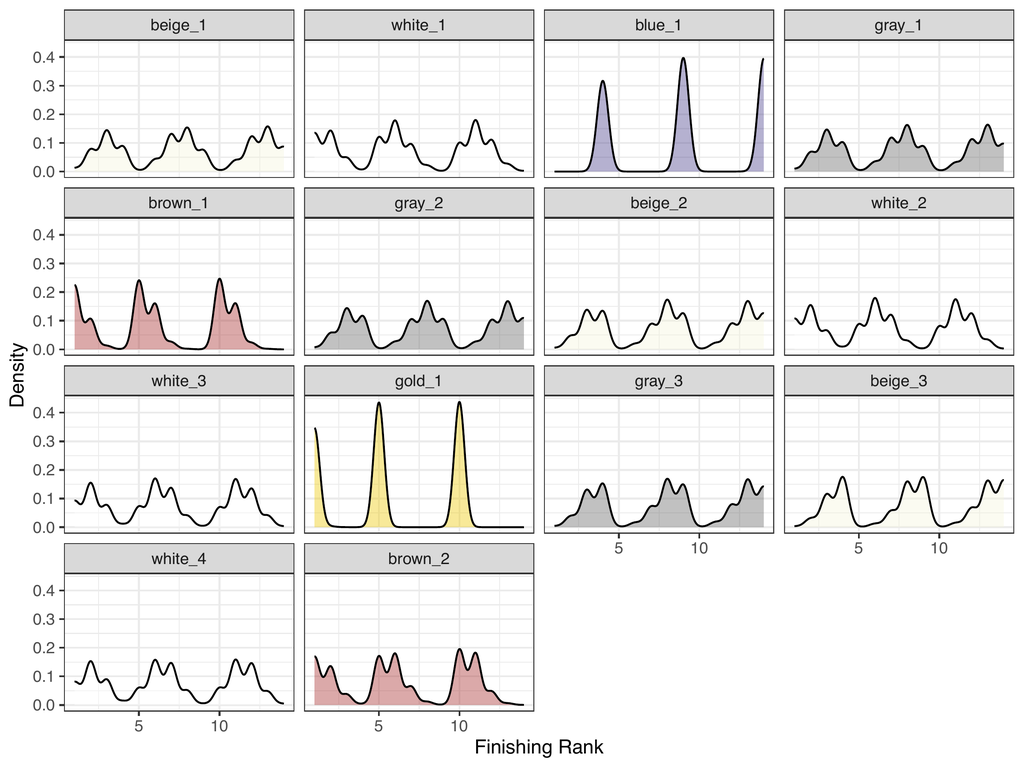

Figure 6: Rank distribution for each dog when the Blue dog is selected.

```r
  finish_df <- melt(results_blue$finish_positions_all)
  colnames(finish_df) <- c("Simulation", "Dog", "FinishRank")

  # Extract the dog's actual colour
  finish_df$ColourName <- sapply(finish_df$Dog, extract_colour_name)

  ggplot(finish_df, aes(x = FinishRank, fill = ColourName)) +
    geom_density(alpha = 0.4, show.legend = FALSE) +
    facet_wrap(~ Dog) +
    labs(
      x = "Finishing Rank",
      y = "Density"
    ) +
    scale_fill_manual(values = dog_color_map) +
    theme_bw()
```

## Gold and Blue Dog Comparisons

Figure 7 compares each dog’s **winning rate** side by side for the “Gold selected” vs. “Blue selected” scenarios, revealing that the difference for most dogs is minimal.

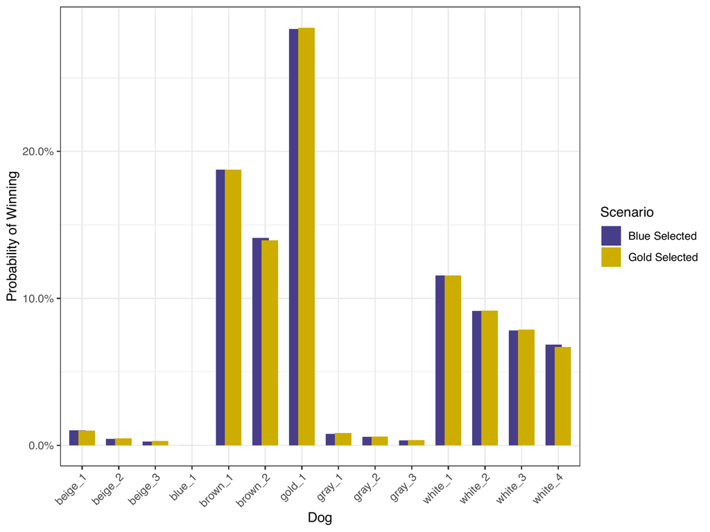

Figure 7: Win rate for each dog under both selection conditions (i.e., Gold and Blue dog selected.

```r
  # 1) Read in saved results
  results_blue <- readRDS("results_blue_selected.rds")
  results_gold <- readRDS("results_gold_selected.rds")

  # 2) Extract each dog's win probabilities as data frames
  df_blue <- data.frame(
    Dog     = names(results_blue$dog_win_probability),
    WinProb = as.numeric(results_blue$dog_win_probability),
    Scenario = "Blue Selected"
  )

  df_gold <- data.frame(
    Dog     = names(results_gold$dog_win_probability),
    WinProb = as.numeric(results_gold$dog_win_probability),
    Scenario = "Gold Selected"
  )

  # 3) Combine them
  df_combined <- rbind(df_blue, df_gold)


  ggplot(df_combined, aes(x = Dog, y = WinProb, fill = Scenario)) +
    geom_col(position = position_dodge(width = 0.5)) +
    scale_fill_manual(values = c("Blue Selected" = "darkslateblue",
                                 "Gold Selected" = "gold3")) +
    labs(
      title = "Comparing Dog Winning Probabilities",
      x = "Dog",
      y = "Probability of Winning",
      fill = "Scenario"
    ) +
    scale_y_continuous(labels = scales::percent_format(accuracy = 0.1)) +
    theme_bw() +
    theme(axis.text.x = element_text(angle = 45, hjust = 1))
```